Dev Log of Jason Ahn

# [R ggplot2] Bar 그래프 그리기

Nov 17, 2019 • 1 min read

R

# ggplot2 Bar 그래프 그리는 방식

- 첫째, x축의 값만 지정하여 빈도를 나타내는 그래프
- 둘째, x축과 y축의 값을 각각 지정하여 그리는 그래프

# 1. x축 값만 지정한 그래프

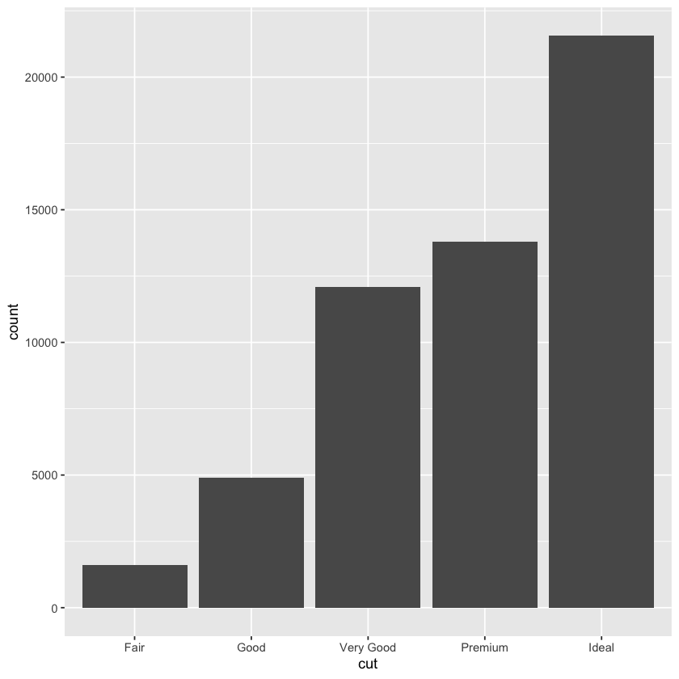

```r
library(ggplot2)
ggplot(diamonds, aes(cut)) + geom_bar()
```

# 2. x축, y축 값을 지정한 그래프

## 1) 기본 bar 그래프

- stat='identity'는 y축의 높이를 데이터의 값으로 하는 bar 그래프의 형태로 지정한다는 것

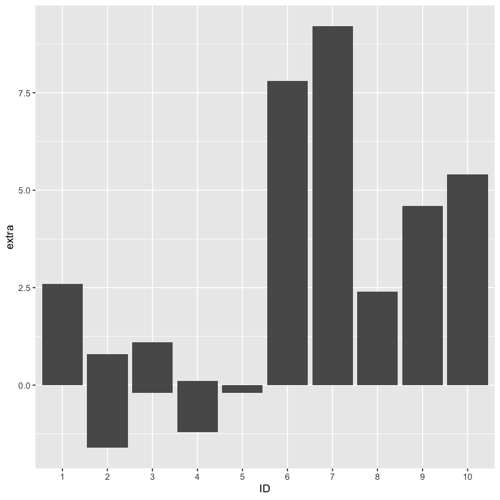

```r
ggplot(sleep, aes(ID, extra)) + geom_bar(stat='identity')
```

## 2) 데이터의 종류를 한 그래프 안에 나눠서 표시해주는 bar 그래프

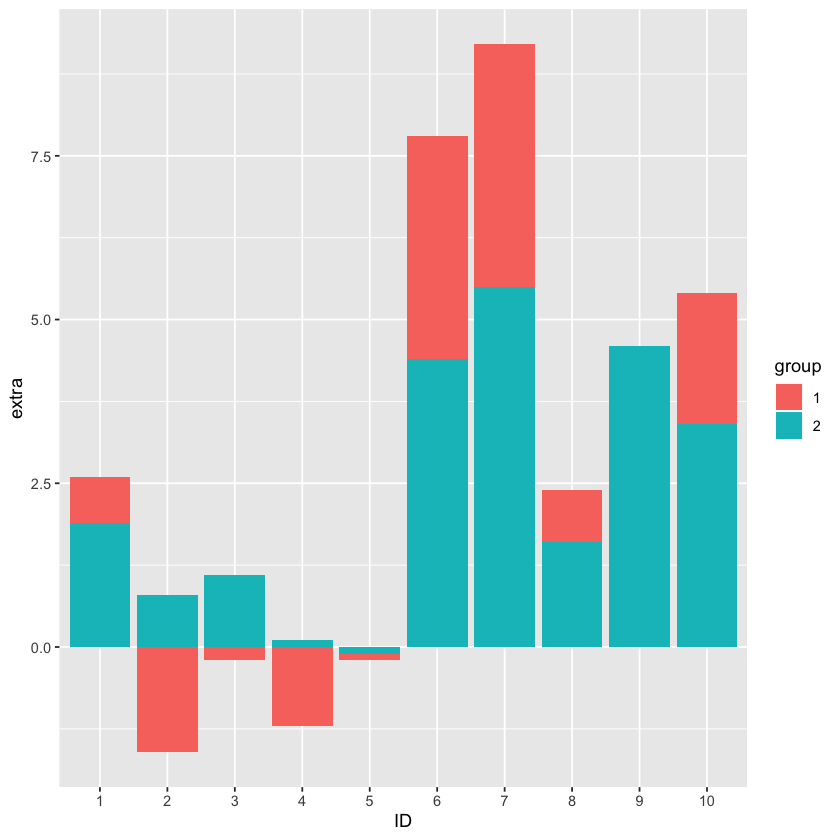

```r
ggplot(sleep, aes(ID, extra, fill=group)) + geom_bar(stat='identity')
```

## 3) 데이터의 종류를 나눠 따로 표시해주는 그래프

- position='dodge'는 막대의 위치를 개별적인 막대로 나란히 표현하라는 명령어
- 단, 나란히 표시할 데이터를 fill 혹은 color 함수를 이용해 반드시 구분지어주어야 함

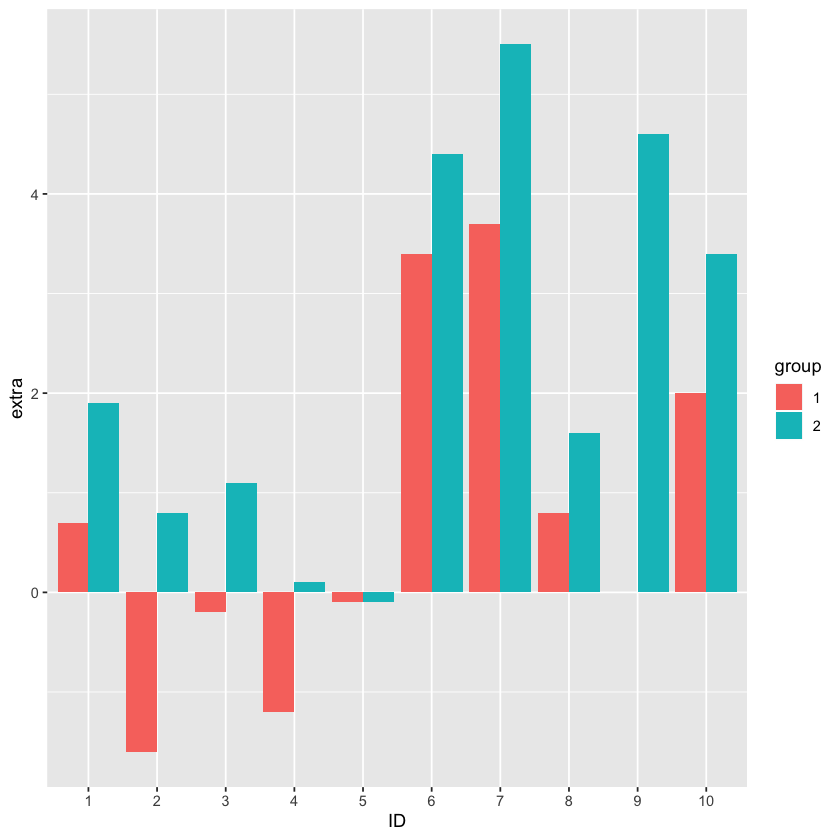

```r
ggplot(sleep, aes(ID, extra, fill=group)) +
    geom_bar(stat='identity', position='dodge')
```

## 4) 데이터의 종류를 비율로 표시해주는 bar 그래프

- position='fill'은 말 그대로 막대 그래프를 화면에 꽉 채워, x값 내의 데이터의 상대적인 비율을 나타내 줄 때 슴

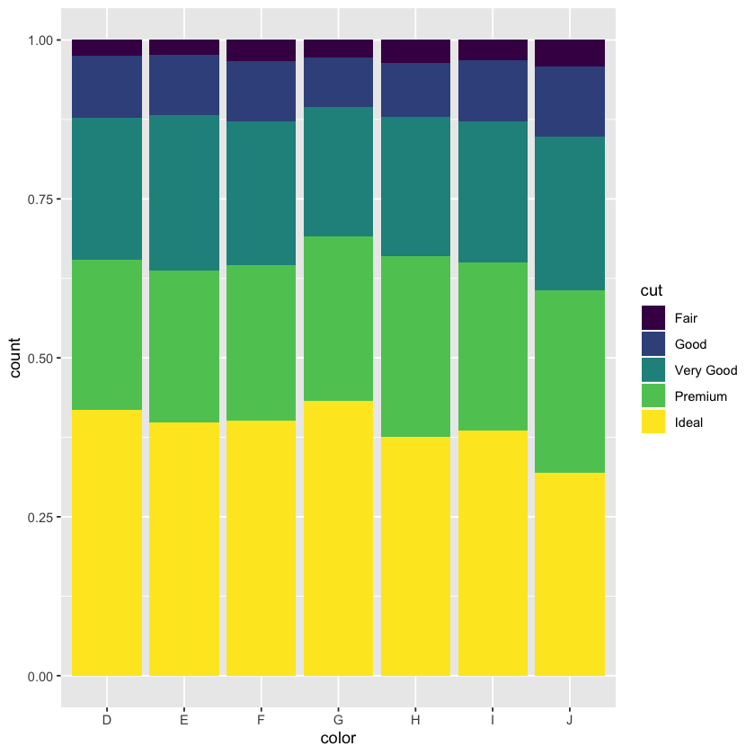

```r
ggplot(diamonds, aes(color, fill=cut)) +
    geom_bar(position='fill')
```

## 5) 가로 그래프

- coord는 'coordinate'의 약자로 조정하고 꾸미는 것을 의미하며, flip은 '뒤집다'의 뜻을 가지고 있음
- 즉, coord_flip()은 x축과 y축의 구성을 뒤집어 표현하라는 명령어이며, x축과 y축의 위치가 바뀜과 동시에 가로의 막대로 값을 표현하는 bar 그래프가 그려지도록 해 줌

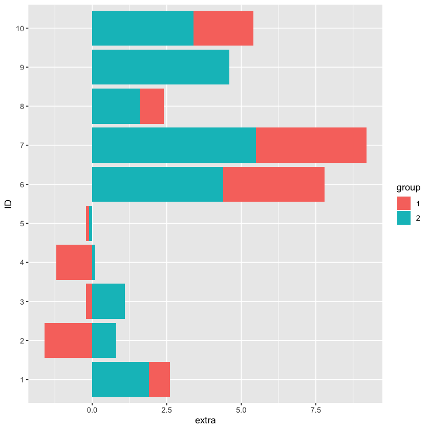

```r
ggplot(sleep, aes(ID, extra, fill=group)) +
    geom_bar(stat='identity') + coord_flip()
```

## 6) 복수의 데이터를 나란히 표현해주는 가로 그래프

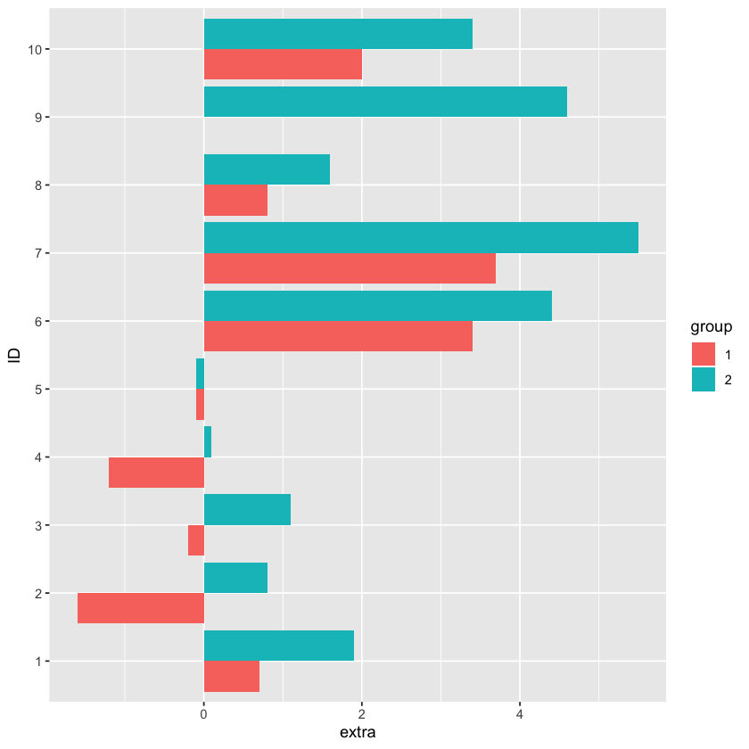

```r
ggplot(sleep, aes(ID, extra, fill=group)) +
    geom_bar(stat='identity', position='dodge') + coord_flip()
```